# [Thu Ha MAI] M2 project based on Lalive, van Ours, and Zweimuller (2006, ReStud): The Duration of Unemployment

## **Question 1. What are the contributions of this study?**

### *What are the objectives, and how do they relate to the established literature?*

This study examines the impact of variations in the benefit replacement rate (RR) and potential benefit duration (PBD), which are the two crucial aspects of unemployment insurance, on the length of unemployment. The 1989 policy shift in Austria is used in the present research to demonstrate the causal relationship between benefit duration and people’s willingness to accept jobs.

An extensive body of theoretical research has demonstrated that a more generous unemployment insurance system (via and/or a longer PBD) will decrease an unemployed person’s best job search effort, leading to a longer period of unemployment. Additionally, these ideas provide insight into how adjustments to the essential elements of unemployment insurance will impact the exit rate. To be more specific, a rise in RR in particular is expected to have the most impact on periods of unemployment, while a rise in PBD will have the greatest impact around the time that benefits run out, causing “spikes” in the unemployment departure rate.

In order to examine the aforementioned results from the theoretical research, the researchers make use of a sizable and informative dataset that enables them to trace employees’ unemployment histories over a lengthy period of time with an aim to evaluate the impact of these changes in unemployment insurance laws. They contrast the total unemployment inflow that occurred two years before to the change in policy with the entire inflow two years thereafter. As a result, they are left with a sizable dataset that enables them to correctly estimate the policy parameters of interest.

### *What is novel about the empirical strategy?*

Policy endogeneity is a recurring criticism against previous studies on the same subject. Benefits are often increased in anticipation of the eligible workers’ job market being worse. Card and Levine (2000) demonstrate that there is a significant policy bias by taking advantage of the variance in benefit length that happened irrespective of labour market conditions. Similar evidence for the Austrian labour market is shown by Lalive and Zweimüller (2004a, b). According to Rød and Zhang’s findings in 2003, for Norwegian unemployed people, the exit rate from unemployment rises significantly in the months before to benefit exhaustion, with the effect being more significant for women than for men. Puhani (2000) discovered that PBD cuts in Poland had no discernible impact on the length of unemployment. In their 2006 study on PBD decreases in Slovenia, Van Ours and Vodopivec discovered significant rises around benefit exhaustion as well as notable effects on the exit rate from unemployment.

The early literature focused on variations in benefit replacement ratios between people to evaluate the effects of RR on unemployment lengths. Calculated unemployment length elasticities with regard to benefit levels range from 0 to 1 per cent (Atkinson and Micklewright, 1991). The prospect of unobserved heterogeneity skewing identification in cross-sectional data makes this literature questionable.

Designing effective policies requires reliable empirical knowledge of how the two primary unemployment insurance factors affect the search behaviour of unemployed workers. The majority of earlier empirical investigations split these “exogenous” variation-induced incentive effects into two categories: benefit level changes and PBD changes. While the implications of changing these factors in ceteris paribus are undoubtedly fascinating in and of themselves, it is not possible to address potentially crucial issues about the proper conception of unemployment insurance. Hence, the researchers of this paper decided to divide the total costs of unemployment insurance funds into costs due to changes in the unemployment insurance system with unchanged behaviour and costs due to behavioural responses of unemployed workers using our parameter estimates to determine the relative importance of the two policy parameters.

### *What are the results and how convincing are these?*

The authors of the paper find that both the rise in RR as well as the expansion of PBD considerably increases the length of unemployment. In line with theoretical assumptions, they show that most of the effect takes place early in the jobless spell in the case of the RR rise and around the dates when benefits expired in the case of the PBD extension.

Although the treated populations’ heterogeneity is obvious, the researchers discover that the effects are rather strong. They specifically discover that both estimated effects are independent of changes in the control groups used to measure the treatment impact. There are two significant outliers despite the size of the impacts being relatively robust. First, older workers respond to PBD extensions more strongly than prime-age workers, and second, older workers are more affected by the cumulative effects of simultaneous changes in RR and PBD. Theoretically, the worse labour market position of older workers and/or the incentives produced by the institutional environment might be used to explain why they have a higher response to changes in unemployment insurance laws (early retirement).

The results also indicate that costs related to behavioural reactions are small for increases in RR, but large for increases in PBD. From these data, a simple policy conclusion may be derived: If policymakers intend to affect incentives, the potential duration of unemployment is a more effective instrument than the level of unemployment benefits.

## **Data Preparation**

```r
# Load the libraries
library(foreign)
library(tidyverse)
```

```r
# Load the dataset
udat <- read.dta("C:/Users/AMSE/Documents/Thu_Ha/Transition_Duration_Models/fi.dta")
udat <- udat[,1:134]
udat <- as_tibble(udat)
```

```r
# Take a look at the dataset
dim(udat)
```

```
[1] 225821    134
```

```r
glimpse(udat[,1:36])
```

```
Rows: 225,821
Columns: 36
$ beginn   <dbl> 10412, 10169, 10624, 10343, 10654, 10101, 10652, 10338, 10705, 10258, 10287, 10077, 10141, 10245, 10245, 10471, 10686, …
$ ein_zus  <dbl> 0, 0, 0, 0, 0, 0, 0, 0, 0, 0, 0, 0, 0, 0, 0, 0, 0, 0, 1, 0, 0, 0, 0, 0, 0, 0, 0, 0, 0, 0, 0, 0, 0, 0, 1, 0, 0, 0, 0, 0,…
$ sfrau    <dbl> 0, 1, 1, 0, 0, 0, 1, 1, 1, 0, 0, 1, 1, 1, 1, 1, 1, 0, 1, 1, 0, 1, 0, 1, 1, 0, 1, 1, 1, 0, 0, 1, 1, 1, 0, 0, 1, 1, 1, 0,…
$ age      <dbl> 51.13758, 54.71595, 54.04791, 54.11636, 46.13005, 42.11909, 54.45859, 47.68241, 46.35455, 46.54894, 41.79603, 46.05339,…
$ after    <dbl> 0, 0, 0, 0, 0, 0, 0, 0, 0, 0, 0, 0, 0, 0, 0, 0, 0, 0, 0, 0, 0, 0, 0, 0, 0, 0, 0, 0, 0, 0, 0, 0, 0, 0, 0, 0, 0, 0, 0, 0,…
$ dur      <dbl> 0.1428571, 0.1428571, 0.1428571, 0.1428571, 0.1428571, 0.1428571, 0.1428571, 0.1428571, 0.1428571, 0.1428571, 0.1428571…
$ nwage_pj <dbl> 11282.729, 8577.623, 6828.051, 10071.884, 6342.333, 6094.196, 8775.981, 8138.359, 12128.852, 7548.013, 11634.375, 11246…
$ e3_5     <dbl> 1, 1, 1, 0, 1, 1, 1, 0, 1, 1, 1, 1, 1, 1, 1, 1, 1, 1, 1, 1, 1, 1, 1, 1, 1, 1, 1, 1, 1, 1, 1, 1, 1, 1, 1, 1, 1, 1, 1, 1,…
$ bdur     <dbl> 30, 30, 30, 20, 30, 30, 30, 20, 30, 30, 30, 30, 30, 30, 30, 30, 30, 30, 30, 30, 30, 30, 30, 30, 30, 30, 30, 30, 30, 30,…
$ y1988    <dbl> 1, 0, 0, 1, 0, 0, 0, 1, 0, 1, 1, 0, 0, 1, 1, 1, 0, 1, 0, 1, 1, 0, 0, 0, 0, 0, 0, 0, 1, 1, 0, 1, 0, 0, 1, 1, 0, 1, 1, 1,…
$ y1989    <dbl> 0, 0, 1, 0, 1, 0, 1, 0, 1, 0, 0, 0, 0, 0, 0, 0, 1, 0, 1, 0, 0, 0, 0, 0, 0, 1, 0, 1, 0, 0, 1, 0, 0, 0, 0, 0, 1, 0, 0, 0,…
$ y1990    <dbl> 0, 0, 0, 0, 0, 0, 0, 0, 0, 0, 0, 0, 0, 0, 0, 0, 0, 0, 0, 0, 0, 0, 0, 0, 0, 0, 0, 0, 0, 0, 0, 0, 0, 0, 0, 0, 0, 0, 0, 0,…
$ y1991    <dbl> 0, 0, 0, 0, 0, 0, 0, 0, 0, 0, 0, 0, 0, 0, 0, 0, 0, 0, 0, 0, 0, 0, 0, 0, 0, 0, 0, 0, 0, 0, 0, 0, 0, 0, 0, 0, 0, 0, 0, 0,…
```

[output cut: 23 more lines]

```r
table(udat$type)
```

```
PBD and RR        PBD         RR    control
     21174      99404      32470      72773
```

```r
# Compute the average spells when the duration is truncated at 104 weeks
udat %>%
  mutate(dur104 = dur,
         dur104 = ifelse(dur104 > 104, 104, dur104)) ->
  udat
```

```r
# Attach the dataset to make the codes more elegant
attach(udat)
```

## **Question 2. (Difference-in-differences) Attempt to replicate Table 4 of the paper**

```r
# Compute the difference between the average duration of unemployment for the control group before and after the reform, which will be used to calculate the Diff-in-diff
diff_control = mean(dur104[after==1 & type=='control']) - mean(dur104[after==0 & type=='control'])
diff_control
```

```
[1] 1.16942
```

```r
# The summary table of the average duration of unemployment of different types
df_summary <- udat %>%
  group_by(type) %>%
  dplyr::summarize(average_before_August1989 = mean(dur104[after==0]),
            N_before_August1989 = sum(after==0),
            se_before_August1989 = sd(dur104[after==0])/sqrt(N_before_August1989),
            average_after_August1989 = mean(dur104[after==1]),
            N_after_August1989 = sum(after==1),
            se_after_August1989 = sd(dur104[after==1])/sqrt(N_after_August1989),
            change_afterbefore = average_after_August1989 - average_before_August1989,
            Dif_in_dif = change_afterbefore - diff_control
            )
df_summary
```

| type | average_before_August1989 | N_before_August1989 | se_before_August1989 | average_after_August1989 | N_after_August1989 | se_after_August1989 | change_afterbefore | Dif_in_dif |
| --- | --- | --- | --- | --- | --- | --- | --- | --- |
| PBD and RR | 18.48832 | 11992 | 0.16178444 | 22.73973 | 9182 | 0.23300208 | 4.251408 | 3.0819876 |
| PBD | 15.83402 | 48294 | 0.07572010 | 18.08298 | 51110 | 0.09118705 | 2.248958 | 1.0795374 |
| RR | 17.10815 | 17160 | 0.11795657 | 19.09596 | 15310 | 0.15225308 | 1.987803 | 0.8183827 |
| control | 14.46226 | 33815 | 0.07823008 | 15.63168 | 38958 | 0.08696947 | 1.169420 | 0.0000000 |

## **Question 3. (Survival Functions) Seek to reproduce Figure 3 in Lalive et al. (2006)**

```r
library(survival)
library(ggplot2)
library(ggsurvfit)
```

```r
# For type PBD and RR

# Filter the data with the type PBD and RR
data_PBDandRR <- filter(udat, type=='PBD and RR')

# Fit the survival model
sfitPBDandRR = survfit(Surv(dur104, uncc)~after, data=data_PBDandRR, type='kaplan-meier')
summary(sfitPBDandRR, times=seq(0, 100, 20))
```

```
Call: survfit(formula = Surv(dur104, uncc) ~ after, data = data_PBDandRR,
    type = "kaplan-meier")

                after=0
 time n.risk n.event survival std.err lower 95% CI upper 95% CI
    0  11992       0   1.0000 0.00000       1.0000       1.0000
   20   3916    7869   0.3356 0.00435       0.3272       0.3443
   40    858    3004   0.0754 0.00246       0.0707       0.0803
   60    400     438   0.0364 0.00176       0.0331       0.0400
   80    258     130   0.0243 0.00146       0.0216       0.0274
  100    199      52   0.0193 0.00131       0.0169       0.0221

                after=1
 time n.risk n.event survival std.err lower 95% CI upper 95% CI
    0   9182       0   1.0000 0.00000       1.0000       1.0000
   20   3558    5427   0.4003 0.00516       0.3903       0.4106
   40   1486    1997   0.1727 0.00403       0.1649       0.1807
   60    594     869   0.0705 0.00276       0.0653       0.0761
   80    361     219   0.0442 0.00223       0.0400       0.0488
  100    265      92   0.0328 0.00195       0.0292       0.0369
```

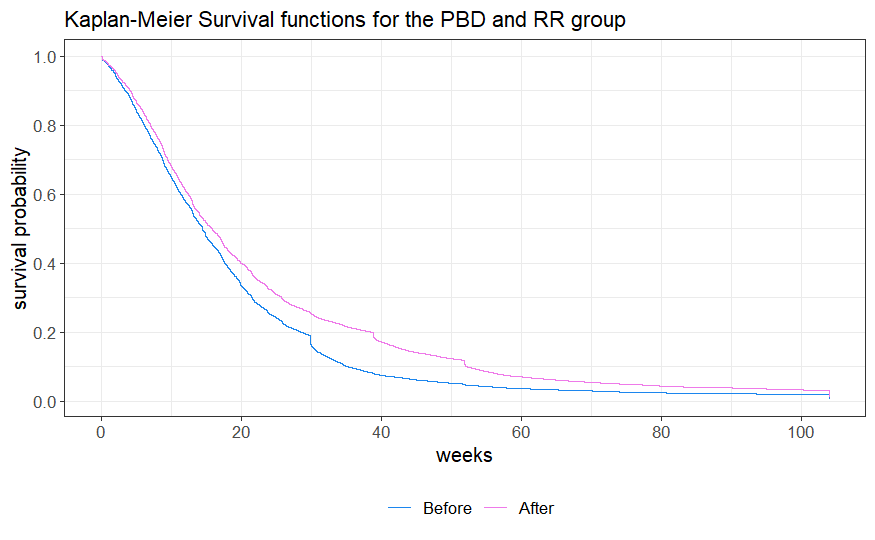

```r
# Plot the survival probability
ggsurvfit(sfitPBDandRR) +
  labs(
    title='Kaplan-Meier Survival functions for the PBD and RR group',
    x = 'weeks',
    y = 'survival probability'
  ) +
  scale_x_continuous(breaks = c(0, 20, 40, 60, 80, 100)) +
  scale_y_continuous(breaks = c(0.0, 0.2, 0.4, 0.6, 0.8, 1.0)) +
  scale_fill_manual(values = c('dodgerblue2', 'orchid2'), labels = c('Before', 'After')) +
  scale_color_manual(values = c('dodgerblue2', 'orchid2'), labels = c('Before', 'After'))
```

```r
# For type PBD

# Filter the data with the type PBD
data_PBD <- filter(udat, type=='PBD')

# Fit the survival model
sfitPBD = survfit(Surv(dur104, uncc)~after, data=data_PBD, type='kaplan-meier')
summary(sfitPBD, times=seq(0, 100, 20))
```

```
Call: survfit(formula = Surv(dur104, uncc) ~ after, data = data_PBD,
    type = "kaplan-meier")

                after=0
 time n.risk n.event survival  std.err lower 95% CI upper 95% CI
    0  48294       0   1.0000 0.000000       1.0000       1.0000
   20  10021   37574   0.2129 0.001879       0.2092       0.2166
   40   2822    7038   0.0617 0.001115       0.0596       0.0639
   60   1487    1270   0.0336 0.000842       0.0320       0.0353
   80    940     487   0.0223 0.000698       0.0210       0.0237
  100    712     193   0.0177 0.000628       0.0165       0.0189

                after=1
 time n.risk n.event survival  std.err lower 95% CI upper 95% CI
    0  51110       0   1.0000 0.000000       1.0000       1.0000
   20  11971   38284   0.2412 0.001910       0.2375       0.2450
   40   5485    6230   0.1141 0.001431       0.1113       0.1169
   60   2639    2741   0.0564 0.001050       0.0544       0.0585
   80   1717     872   0.0376 0.000872       0.0359       0.0393
  100   1310     367   0.0295 0.000780       0.0280       0.0310
```

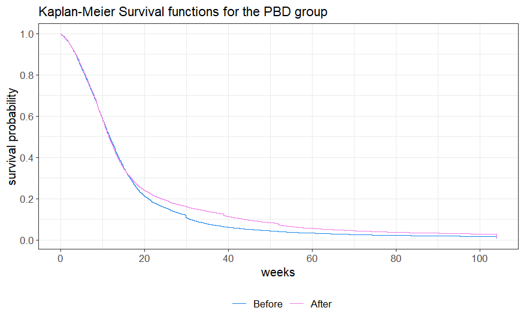

```r
# Plot the survival probability
ggsurvfit(sfitPBD) +
  labs(
    title='Kaplan-Meier Survival functions for the PBD group',
    x = 'weeks',
    y = 'survival probability'
  ) +
  scale_x_continuous(breaks = c(0, 20, 40, 60, 80, 100)) +
  scale_y_continuous(breaks = c(0.0, 0.2, 0.4, 0.6, 0.8, 1.0)) +
  scale_fill_manual(values = c('dodgerblue2', 'orchid2'), labels = c('Before', 'After')) +
  scale_color_manual(values = c('dodgerblue2', 'orchid2'), labels = c('Before', 'After'))
```

```r
# For type RR

# Filter the data with the type RR
data_RR <- filter(udat, type=='RR')

# Fit the survival model
sfitRR = survfit(Surv(dur104, uncc)~after, data=data_RR, type='kaplan-meier')
summary(sfitRR, times=seq(0, 100, 20))
```

```
Call: survfit(formula = Surv(dur104, uncc) ~ after, data = data_RR,
    type = "kaplan-meier")

                after=0
 time n.risk n.event survival std.err lower 95% CI upper 95% CI
    0  17160       0   1.0000 0.00000       1.0000       1.0000
   20   5037   11549   0.3089 0.00359       0.3020       0.3161
   40    834    4096   0.0535 0.00178       0.0502       0.0571
   60    427     374   0.0289 0.00135       0.0264       0.0317
   80    263     146   0.0188 0.00111       0.0167       0.0211
  100    204      48   0.0153 0.00101       0.0134       0.0174

                after=1
 time n.risk n.event survival std.err lower 95% CI upper 95% CI
    0  15310       0   1.0000 0.00000       1.0000       1.0000
   20   5096    9655   0.3524 0.00393       0.3448       0.3602
   40   1205    3783   0.0868 0.00236       0.0823       0.0915
   60    697     452   0.0534 0.00191       0.0498       0.0573
   80    423     242   0.0345 0.00157       0.0315       0.0377
  100    320      86   0.0273 0.00142       0.0247       0.0303
```

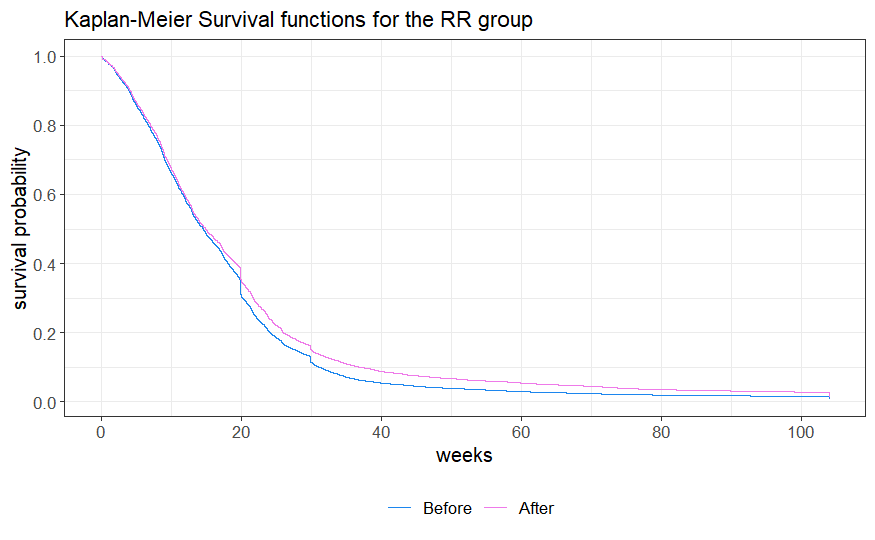

```r
# Plot the survival probability
ggsurvfit(sfitRR) +
  labs(
    title='Kaplan-Meier Survival functions for the RR group',
    x = 'weeks',
    y = 'survival probability'
  ) +
  scale_x_continuous(breaks = c(0, 20, 40, 60, 80, 100)) +
  scale_y_continuous(breaks = c(0.0, 0.2, 0.4, 0.6, 0.8, 1.0)) +
  scale_fill_manual(values = c('dodgerblue2', 'orchid2'), labels = c('Before', 'After')) +
  scale_color_manual(values = c('dodgerblue2', 'orchid2'), labels = c('Before', 'After'))
```

```r
# For type Control

# Filter the data with the type Control
data_control <- filter(udat, type=='control')

# Fit the survival model
sfitcontrol = survfit(Surv(dur104, uncc)~after, data=data_control, type='kaplan-meier')
summary(sfitcontrol, times=seq(0, 100, 20))
```

```
Call: survfit(formula = Surv(dur104, uncc) ~ after, data = data_control,
    type = "kaplan-meier")

                after=0
 time n.risk n.event survival  std.err lower 95% CI upper 95% CI
    0  33815       0   1.0000 0.000000       1.0000       1.0000
   20   6421   26088   0.2032 0.002241       0.1989       0.2076
   40   1411    4765   0.0482 0.001225       0.0459       0.0507
   60    700     637   0.0258 0.000925       0.0240       0.0277
   80    420     249   0.0164 0.000756       0.0150       0.0179
  100    295      99   0.0124 0.000670       0.0111       0.0138

                after=1
 time n.risk n.event survival  std.err lower 95% CI upper 95% CI
    0  38958       0   1.0000 0.000000       1.0000       1.0000
   20   8053   29429   0.2212 0.002151       0.2170       0.2255
   40   2326    5470   0.0678 0.001330       0.0653       0.0705
   60   1361     856   0.0422 0.001079       0.0401       0.0444
   80    849     451   0.0278 0.000900       0.0261       0.0296
  100    625     172   0.0220 0.000814       0.0205       0.0237
```

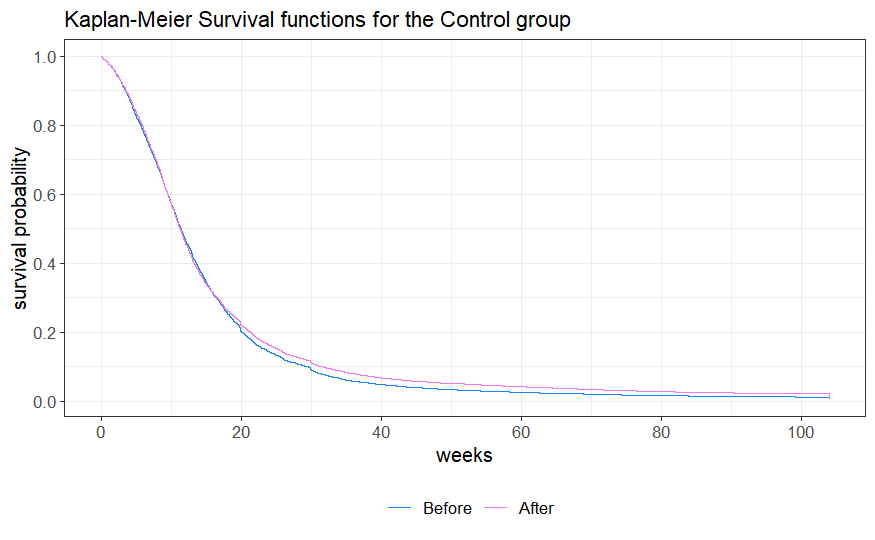

```r
# Plot the survival probability
ggsurvfit(sfitcontrol) +
  labs(
    title='Kaplan-Meier Survival functions for the Control group',
    x = 'weeks',
    y = 'survival probability'
  ) +
  scale_x_continuous(breaks = c(0, 20, 40, 60, 80, 100)) +
  scale_y_continuous(breaks = c(0.0, 0.2, 0.4, 0.6, 0.8, 1.0)) +
  scale_fill_manual(values = c('dodgerblue2', 'orchid2'), labels = c('Before', 'After')) +
  scale_color_manual(values = c('dodgerblue2', 'orchid2'), labels = c('Before', 'After'))
```

## **Question 4. (KM estimates of the unemployment exit hazard): Seek to reproduce Figure 4 in Lalive et al. (2006)**

```r
library(bshazard)
```

```r
# The bshazard function adjusts for covariates rather than stratify by covariates
# This means that we need to divide the dataset into strata and calculate the smoothed hazards separately

# For type PBD and RR
as.data.frame.bshazard <- function(x, ...) {
    with(x, data.frame(time, hazard, lower.ci, upper.ci))
}
hazards_PBDandRR <- group_by(data_PBDandRR, after) %>%
    do(as.data.frame(bshazard(Surv(dur104, uncc)~1, data=., verbose=FALSE, degree=2))) %>%
    ungroup
```

```
|================================================================================================================|100% ~0 s remaining
```

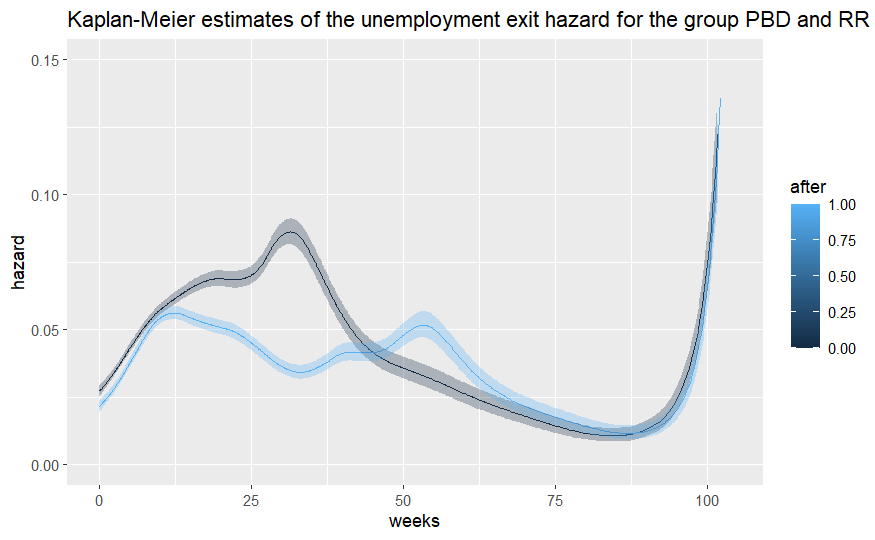

```r
ggplot(hazards_PBDandRR, aes(x=time, y=hazard, group=after)) + geom_line(aes(col=after)) +
    geom_ribbon(aes(ymin=lower.ci, ymax=upper.ci, fill=after), alpha=0.3) + ylim(0, 0.15) + xlim(0, 104) +
    xlab('weeks') + ylab('hazard') + ggtitle('Kaplan-Meier estimates of the unemployment exit hazard for the group PBD and RR')
```

```r
# For type PBD

hazards_PBD <- group_by(data_PBD, after) %>%
    do(as.data.frame(bshazard(Surv(dur104, uncc)~1, data=., verbose=FALSE, degree=2))) %>%
    ungroup
```

```
|================================================================================================================|100% ~0 s remaining
```

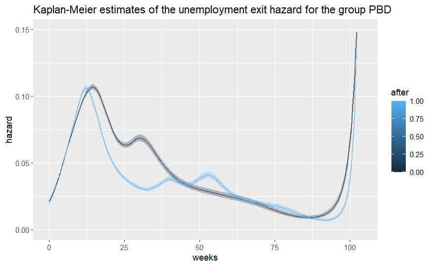

```r
ggplot(hazards_PBD, aes(x=time, y=hazard, group=after)) + geom_line(aes(col=after)) +
    geom_ribbon(aes(ymin=lower.ci, ymax=upper.ci, fill=after), alpha=0.3) + ylim(0, 0.15) + xlim(0, 104) +
    xlab('weeks') + ylab('hazard') + ggtitle('Kaplan-Meier estimates of the unemployment exit hazard for the group PBD')
```

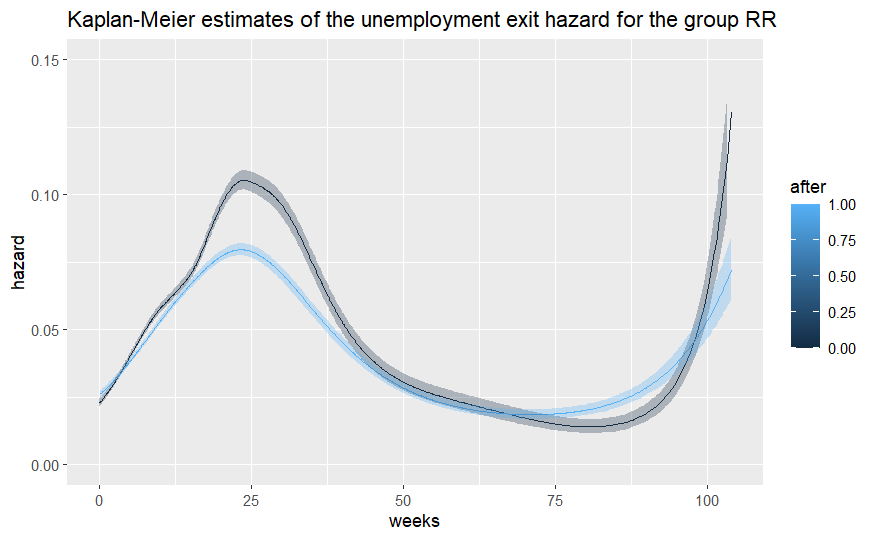

```r
# For type RR

hazards_RR <- group_by(data_RR, after) %>%
    do(as.data.frame(bshazard(Surv(dur104, uncc)~1, data=., verbose=FALSE, degree=2))) %>%
    ungroup
ggplot(hazards_RR, aes(x=time, y=hazard, group=after)) + geom_line(aes(col=after)) +
    geom_ribbon(aes(ymin=lower.ci, ymax=upper.ci, fill=after), alpha=0.3) + ylim(0, 0.15) + xlim(0, 104) +
    xlab('weeks') + ylab('hazard') + ggtitle('Kaplan-Meier estimates of the unemployment exit hazard for the group RR')
```

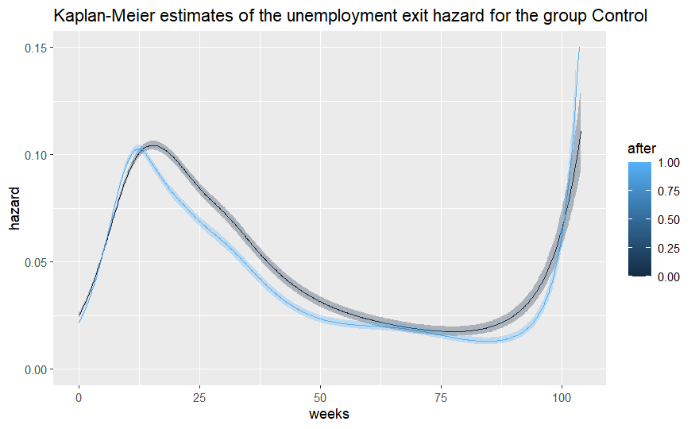

```r
# For type Control

hazards_control <- group_by(data_control, after) %>%
    do(as.data.frame(bshazard(Surv(dur104, uncc)~1, data=., verbose=FALSE, degree=2))) %>%
    ungroup
ggplot(hazards_control, aes(x=time, y=hazard, group=after)) + geom_line(aes(col=after)) +
    geom_ribbon(aes(ymin=lower.ci, ymax=upper.ci, fill=after), alpha=0.3) + ylim(0, 0.15) + xlim(0, 104) +
    xlab('weeks') + ylab('hazard') + ggtitle('Kaplan-Meier estimates of the unemployment exit hazard for the group Control')
```

## **Question 5. Estimate the causal treatment effect in a PH model**

```r
# Prepare to run the PD model

udat %>%
  mutate(all = tr * (t39 + t52) ) ->
  udat

breaks <- seq(from=3,to=59, by=4)
labels <- paste("(", c(0,breaks), ",", c(breaks, 104), "]", sep="")

gux <- survSplit(Surv(dur104, uncc) ~., data=udat, cut=breaks,
                 end="time", event="death", start="start", episode="interval")

gux %>%
  mutate(exposure=time-start,
         interval=factor(interval+1, labels=labels)) ->
  gux

dim(gux)
```

```
[1] 1057906     139
```

```r
library(stargazer)
```

```r
# Set up the PWE PH model with the main variables stated in the paper

pwe <- glm(death ~ interval +
             t39 + t52 + tr +
             all + after0 +
             t39_a0 + t52_a0 + tr_a0 +
             t39tra0 + t52tra0,
             offset=log(exposure), data=gux, family=poisson)

stargazer(pwe,
          dep.var.caption="", dep.var.labels="",
          keep=1:15,
          omit.table.layout="n", star.cutoffs=NA,
          keep.stat=c("n", "ll"), no.space=TRUE,
          header=FALSE,
          title="The PWE model", type="text"
)
```

```
The PWE model
=============================

-----------------------------
interval(3,7]       0.584
                   (0.009)
interval(7,11]      1.018
                   (0.009)
interval(11,15]     1.164
                   (0.009)
interval(15,19]     1.023
                   (0.010)
interval(19,23]     1.065
                   (0.011)
interval(23,27]     0.785
                   (0.013)
interval(27,31]     0.840
                   (0.014)
interval(31,35]     0.607
                   (0.016)
interval(35,39]     0.448
                   (0.019)
interval(39,43]     0.342
                   (0.022)
interval(43,47]     0.157
                   (0.025)
interval(47,51]     -0.011
                   (0.029)
interval(51,55]     0.477
                   (0.025)
interval(55,59]     0.038
                   (0.032)
interval(59,104]    -0.019
                   (0.014)
-----------------------------
Observations      1,057,906
Log Likelihood   -706,079.600
=============================
```

```r
# Set up the PWE PH model with several control variables

pwe_control <- glm(death ~ interval +
             t39 + t52 + tr +
             all + after0 +
             t39_a0 + t52_a0 + tr_a0 +
             t39tra0 + t52tra0 +
             age + married + single + divorced +
             f_marr + f_single + f_divor +
             med_educ + hi_educ +
             seasonal + manuf +
             y1988 + y1989 + y1990 + y1991 +
             q2 + q3 + q4
             ,
             offset=log(exposure), data=gux, family=poisson)

stargazer(pwe_control,
          dep.var.caption="", dep.var.labels="",
          keep=1:15,
          omit.table.layout="n", star.cutoffs=NA,
          keep.stat=c("n", "ll"), no.space=TRUE,
          header=FALSE,
          title="The PWE model with several control variables", type="text"
)
```

```
The PWE model with several control variables
=============================

-----------------------------
interval(3,7]       0.593
                   (0.009)
interval(7,11]      1.062
                   (0.009)
interval(11,15]     1.271
                   (0.009)
interval(15,19]     1.192
                   (0.010)
interval(19,23]     1.274
                   (0.011)
interval(23,27]     1.018
                   (0.013)
interval(27,31]     1.086
                   (0.014)
interval(31,35]     0.857
                   (0.017)
interval(35,39]     0.705
                   (0.019)
interval(39,43]     0.601
                   (0.022)
interval(43,47]     0.416
                   (0.025)
interval(47,51]     0.247
                   (0.029)
interval(51,55]     0.731
                   (0.025)
interval(55,59]     0.290
                   (0.032)
interval(59,104]    0.244
                   (0.015)
-----------------------------
Observations      1,057,906
Log Likelihood   -694,472.800
=============================
```